# STAT_205_HW2

HONGLEI REN

1/20/2020

## Problem 1

### 1.1 Propose a conjugate Normal Prior $\mu \sim N(\mu_0, \tau_0)$

According to the percentile table of standard normal distribution, we know that:

$$z = \frac{x - \mu_0}{\sqrt{\tau_0}} = \frac{42 - 40}{\sqrt{\tau_0}} = \frac{2}{\sqrt{\tau_0}}= 1.96$$
, and we got $\tau_0 = (\frac{2}{1.96})^2$. Therefore, the Normal prior is $\mu \sim N(40, (\frac{2}{1.96})^2)$.

### 1.2 The Posterior Expectation

Suppose $\tau_0 = \frac{\sigma^2}{m} = \frac{10^2}{m} = (\frac{2}{1.96})^2$, therefore, $m = 96.04$.

Then, we have $Y|\mu, \sigma^2 \sim Normal(\mu, 10^2), \mu \sim N(40, \frac{10^2}{96.04})$. The posterior is:
$$\mu|Y \sim N(w\overline{Y} + (1 - w) \mu_0, \frac{\sigma^2}{n + m})$$
, where $w = \frac{n}{n + m}$, $\overline{Y} = 45.283$ is the sample mean.

Therefore, the posterior mean is $40.586$, which is very close to the prior mean although the sample mean $45.283$ is much higher, and this is caused by a strong prior.

In our case, the relative contribution of prior is $0.89$ and data for posterior expectation is $0.11$.

### 1.3 The Posterior Distribution

From the figure below, we can see that posterior distribution $mu$ shifts towards right of the prior, which means the data suggest average snowfall observed are higher than our prior knowledge.

```r
#Data
snowfall = c(38.6, 42.4, 57.5, 40.5, 51.7, 67.1, 33.4, 60.9, 64.1, 40.1, 40.7, 6.4)
mean_snowfall = mean(snowfall)

#Params
n = length(snowfall)
m = 96.04
mu0 = 40
sigma = 10
w = n / (n + m)
mu = seq(35, 45, 0.5)
```

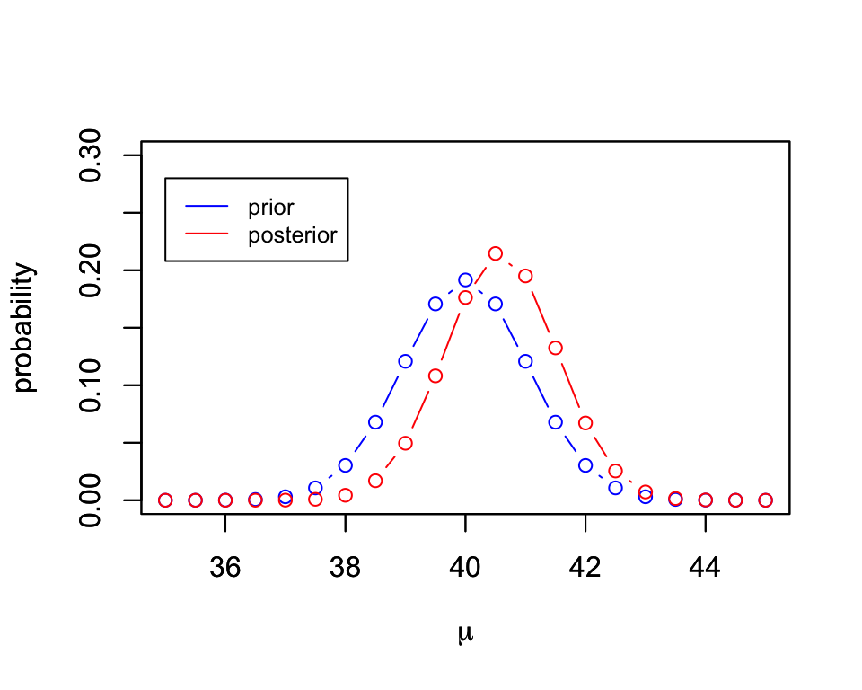

```r
# Calculate prior and posterior
prior_mu = dnorm(mu, mean = mu0, sd= (sigma^2) / m)
posterior_mean = w * mean_snowfall + (1 - w) * mu0
posterior_sd = (sigma^2) / (n + m)
posterior_mu = dnorm(mu, mean = posterior_mean, sd= posterior_sd)

# Plotting
plot(mu, prior_mu/sum(prior_mu),col="blue", type="b", xlab = expression(mu), ylab = "probability", ylim=range(c(0,0.3)))
par(new=TRUE)
plot(mu, posterior_mu/sum(posterior_mu), col="red", type="b", xlab = expression(mu), ylab = "probability", ylim=range(c(0,0.3)))
legend(35, 0.28, legend=c("prior", "posterior"),
       col=c("blue", "red"), lty=1:1, cex=0.8)
```

### 1.4 Quantiles of Posterior Distribution

```r
S = 100000 #Sample size
mu_star = rnorm(S, posterior_mean, posterior_sd)
pct_10 = quantile(mu_star, 0.1)
pct_10
```

```
##      10%
## 39.39421
```

```r
pct_90 = quantile(mu_star, 0.9)
pct_90
```

```
##      90%
## 41.77048
```

The $10\%$ quantiles of the posterior distribution is 39.3942072 and the and $90\%$ percentile is 41.7704777.

### 1.5 Posterior mean of log($\mu$)

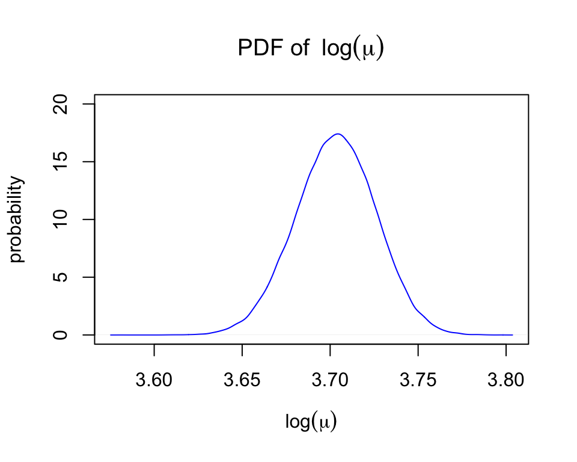

```r
S = 100000 #Sample size
mu_star = rnorm(S, posterior_mean, posterior_sd)
log_mu = log(mu_star)
mean_log_mu = mean(log_mu)
# Plotting
plot(density(log_mu),col="blue", type="l", xlab = expression(log(mu)), ylab = "probability", ylim=range(c(0, 20.0)), main=expression("PDF of " ~ log(mu)))
legend(3.5, 0.28, legend=c("log(mu)"),
       col=c("blue"), lty=1:1, cex=0.8)
```

```r
mean_log_mu
```

```
## [1] 3.703151
```

## Problem 2

### 2.1 Derive posterior

The number of ASE for $N$ patient follows $Y \sim Poisson(N \lambda)$ and $\lambda \sim Gamma(a, b)$.

The likelihood function is :
$$f(Y|\lambda) \propto e^{-N \lambda} \lambda^Y$$
, where $N = 50, Y = 12 + 6*2 + 2 * 10 = 44$.

The prior function is:
$$\pi(\lambda) \propto e^{-b \lambda} \lambda^a$$

Therefore, the posterior is:
$$p(\lambda | Y) \propto e^{- N \lambda} \lambda^Y e^{-b \lambda} \lambda^a \propto e^{-B \lambda} * \lambda^A$$
, where $A = a + Y$, $B = b + N$.
$$p(\lambda | Y) = Gamma(A, B)$$
.

### 2.2 Posterior distribution

Given $a = b = 0.01$, the posterior is
$$p(\lambda | Y) = Gamma(44.01, 50.01)$$
.

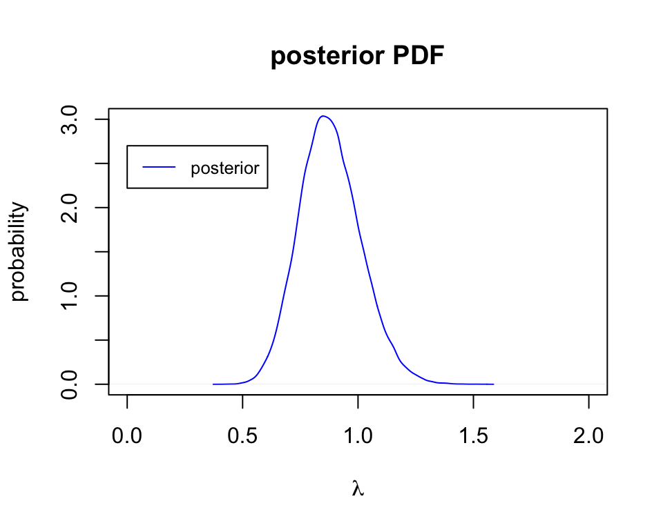

```r
N = 50
Y = 44
a = b = 0.01
A = Y + a
B = N + b
S = 100000
posterior_lambda = rgamma(S, shape = A, rate=B)
posterior_mean = mean(posterior_lambda)
# Plotting
plot(density(posterior_lambda), col="blue", type="l", xlab = expression(lambda), ylab = "probability", main = "posterior PDF", xlim = range(c(0,2)), ylim=range(c(0,3)))
legend(0, 2.7, legend=c( "posterior"),
       col=c("blue"), lty=1:1, cex=0.8)
```

Posterior Mean is 0.880264, and the $95\%$ credible interval is (0.6393088, 1.1586223).

### 2.3 Sensitivity Analysis

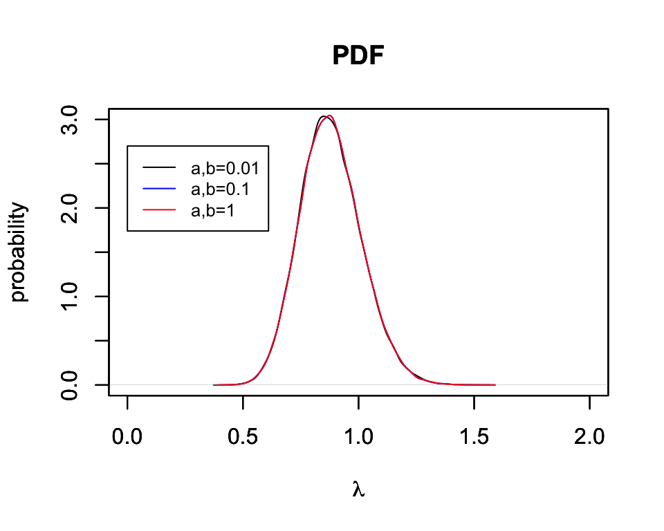

```r
posterior_lambda_2 = rgamma(S, shape = 44.1, rate=50.1)
posterior_lambda_3 = rgamma(S, shape = 45, rate=51)
# Plotting
plot(density(posterior_lambda), col="black", type="l", xlab = expression(lambda), ylab = "probability", main = "PDF", xlim = range(c(0,2)), ylim=range(c(0,3)))
par(new=T)
plot(density(posterior_lambda_2),col="blue", type="l", xlim = range(c(0,2)),ylim=range(c(0,3)), xlab = expression(lambda), ylab = "probability", main = "PDF")
par(new=T)
plot(density(posterior_lambda_2), col="red", type="l", xlab = expression(lambda), ylab = "probability", main = "PDF", xlim = range(c(0,2)), ylim=range(c(0,3)))
legend(0, 2.7, legend=c("a,b=0.01", "a,b=0.1", "a,b=1"),
       col=c("black", "blue", "red"), lty=1:1, cex=0.8)
```

### 2.4 Compare Fitted Poisson with data

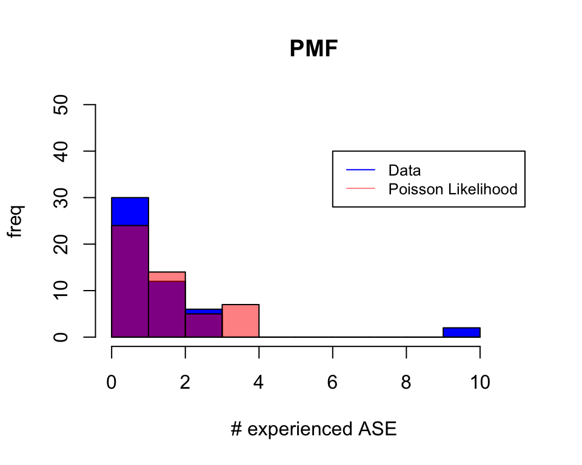

```r
data = c(rep(0, 30), rep(1, 12), rep(2, 6), rep(10, 2))
result = rpois(N, lambda = posterior_mean)
hist(data, col="blue", xlim = range(c(0, 11)),ylim=range(c(0, N)),breaks = 0:10,right=F, xlab = "# experienced ASE", ylab = "freq", main = "PMF")
hist(result, xlim = range(c(0, 11)),ylim=range(c(0, N)),breaks = 0:10,right=F, xlab = "# experienced ASE", ylab = "freq", main = "PMF", col=rgb(1,0,0,0.5), add=T)
legend(6, 40, legend=c("Data", "Poisson Likelihood"),
       col=c("blue", rgb(1,0,0,0.5)), lty=1:1, cex=0.8)
```

### 2.5 Probabilty that new medication has higher side effect rate than the previous one

```r
p1 = sum(posterior_lambda > 1, na.rm = T) / S
p2 = sum(posterior_lambda_2 > 1, na.rm = T) / S
p3 = sum(posterior_lambda_3 > 1, na.rm = T) / S
```

The probabilty that new medication has higher side effect rate than the previous one (p) is :

For $a = b = 0.01$, p = 0.18065

For $a = b = 0.1$, p = 0.18179

For $a = b = 1$, p = 0.18317

It can be seen, the probability is not sensitive to prior params.

### Problem 3 Wildfires

Because $E(X) = \frac{a}{b}, Var(X) = \frac{a}{b^2}$, therefore, by setting our goal $E(X) = \frac{a}{b}= 75, Var(X) = \frac{a}{b^2} = 100$. We get: $a = 56.25, b = 0.75$

Therefore, the prior can be set to $Gamma(a = 56.25, b = 0.75)$.